# Lending.com Classifier

For this project we will be exploring publicly available data from LendingClub.com. Lending Club connects people who need money (borrowers) with people who have money (investors). Hopefully, as an investor you would want to invest in people who showed a profile of having a high probability of paying you back. We will try to create a model that will help predict this.

We will use lending data from 2007-2010 and be trying to classify and predict whether or not the borrower paid back their loan in full.

# Data And Setup

```python
import pandas as pd
import numpy as np
import seaborn as sns
import matplotlib.pyplot as plt
import warnings
warnings.filterwarnings('ignore')

sns.set_style('whitegrid')
%matplotlib inline
plt.rcParams["patch.force_edgecolor"] = True

loans = pd.read_csv('loan_data.csv')
loans.info()
```

```
<class 'pandas.core.frame.DataFrame'>
RangeIndex: 9578 entries, 0 to 9577
Data columns (total 14 columns):
credit.policy        9578 non-null int64
purpose              9578 non-null object
int.rate             9578 non-null float64
installment          9578 non-null float64
log.annual.inc       9578 non-null float64
dti                  9578 non-null float64
fico                 9578 non-null int64
days.with.cr.line    9578 non-null float64
revol.bal            9578 non-null int64
revol.util           9578 non-null float64
inq.last.6mths       9578 non-null int64
delinq.2yrs          9578 non-null int64
pub.rec              9578 non-null int64
not.fully.paid       9578 non-null int64
dtypes: float64(6), int64(7), object(1)
memory usage: 1.0+ MB
```

```python
loans.head()
```

|  | credit.policy | purpose | int.rate | installment | log.annual.inc | dti | fico | days.with.cr.line | revol.bal | revol.util | inq.last.6mths | delinq.2yrs | pub.rec | not.fully.paid |
| --- | --- | --- | --- | --- | --- | --- | --- | --- | --- | --- | --- | --- | --- | --- |
| 0 | 1 | debt_consolidation | 0.1189 | 829.10 | 11.350407 | 19.48 | 737 | 5639.958333 | 28854 | 52.1 | 0 | 0 | 0 | 0 |
| 1 | 1 | credit_card | 0.1071 | 228.22 | 11.082143 | 14.29 | 707 | 2760.000000 | 33623 | 76.7 | 0 | 0 | 0 | 0 |
| 2 | 1 | debt_consolidation | 0.1357 | 366.86 | 10.373491 | 11.63 | 682 | 4710.000000 | 3511 | 25.6 | 1 | 0 | 0 | 0 |
| 3 | 1 | debt_consolidation | 0.1008 | 162.34 | 11.350407 | 8.10 | 712 | 2699.958333 | 33667 | 73.2 | 1 | 0 | 0 | 0 |
| 4 | 1 | credit_card | 0.1426 | 102.92 | 11.299732 | 14.97 | 667 | 4066.000000 | 4740 | 39.5 | 0 | 1 | 0 | 0 |

# Exploratory Data Analysis

Let's do some data visualization! We'll use seaborn and pandas built-in plotting capabilities.

**Let's Create a count plot of Credit.policy**

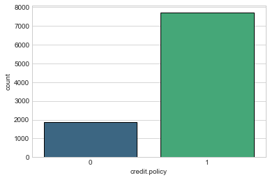

```python
sns.countplot(loans['credit.policy'], palette='viridis')
```

**Let's Create dist plot of interest rate**

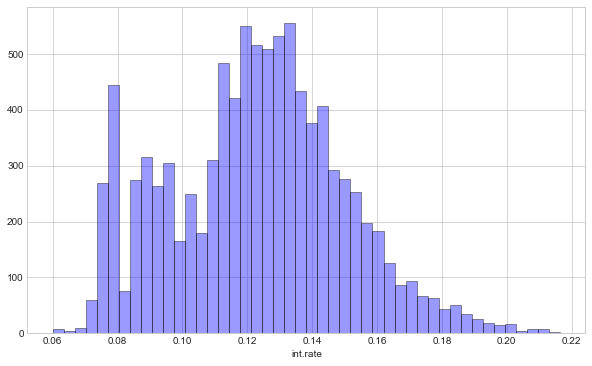

```python
plt.figure(figsize=(10,6))
sns.distplot(loans['int.rate'], kde=False, color='blue')
```

**Let's Create a histogram of two FICO distributions on top of each other, one for each credit.policy outcome.**

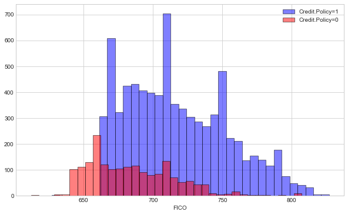

```python
plt.figure(figsize=(10,6))
loans[loans['credit.policy'] == 1]['fico'].hist(alpha = 0.5, color='blue',bins=35,label='Credit.Policy=1')
loans[loans['credit.policy'] == 0]['fico'].hist(alpha = 0.5, color='red',bins=35,label='Credit.Policy=0')
plt.xlabel('FICO')
plt.legend()
```

**Create a similar figure, except this time select by the not.fully.paid column.**

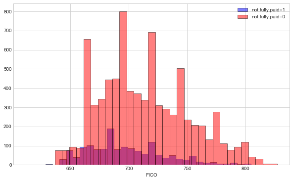

```python
plt.figure(figsize=(10,6))
loans[loans['not.fully.paid'] == 1]['fico'].hist(alpha = 0.5, color='blue',bins=35,label='not.fully.paid=1')
loans[loans['not.fully.paid'] == 0]['fico'].hist(alpha = 0.5, color='red',bins=35,label='not.fully.paid=0')
plt.xlabel('FICO')
plt.legend()
```

**Create a countplot using seaborn showing the counts of loans by purpose, with the color hue defined by not.fully.paid.**

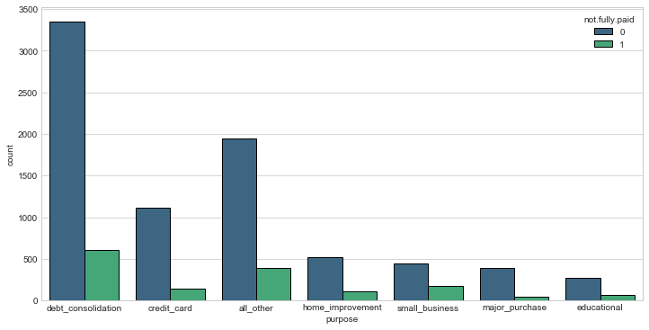

```python
plt.figure(figsize=(12,6))
plt.tight_layout()
sns.countplot(data = loans, x='purpose', hue='not.fully.paid', palette='viridis')
```

**Let's see the trend between FICO score and interest rate. Recreate the following jointplot.**

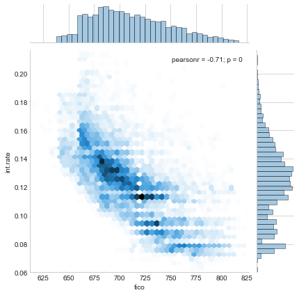

```python
sns.jointplot(data=loans, x='fico', y='int.rate', kind='hex')
```

**Let's Create the following lmplots to see if the trend differed between not.fully.paid and credit.policy.**

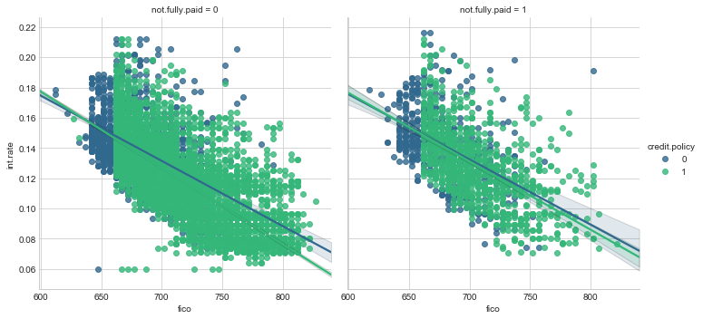

```python
plt.figure(figsize=(11,7))
sns.lmplot(data = loans, x='fico', y='int.rate', col='not.fully.paid', hue='credit.policy', palette='viridis')
```

# Setting up the Data

Let's get ready to set up our data for our Random Forest Classification Model!

## Categorical Features

Notice that the **purpose** column as categorical

That means we need to transform them using dummy variables so sklearn will be able to understand them. Let's do this in one clean step using pd.get_dummies.

**Now use pd.get_dummies(loans,columns=cat_feats,drop_first=True) to create a fixed larger dataframe that has new feature columns with dummy variables. Set this dataframe as final_data.**

```python
final_data = pd.get_dummies(loans,columns=['purpose'],drop_first=True)
final_data.head()
```

|  | credit.policy | int.rate | installment | log.annual.inc | dti | fico | days.with.cr.line | revol.bal | revol.util | inq.last.6mths | delinq.2yrs | pub.rec | not.fully.paid | purpose_credit_card | purpose_debt_consolidation | purpose_educational | purpose_home_improvement | purpose_major_purchase | purpose_small_business |
| --- | --- | --- | --- | --- | --- | --- | --- | --- | --- | --- | --- | --- | --- | --- | --- | --- | --- | --- | --- |
| 0 | 1 | 0.1189 | 829.10 | 11.350407 | 19.48 | 737 | 5639.958333 | 28854 | 52.1 | 0 | 0 | 0 | 0 | 0 | 1 | 0 | 0 | 0 | 0 |
| 1 | 1 | 0.1071 | 228.22 | 11.082143 | 14.29 | 707 | 2760.000000 | 33623 | 76.7 | 0 | 0 | 0 | 0 | 1 | 0 | 0 | 0 | 0 | 0 |
| 2 | 1 | 0.1357 | 366.86 | 10.373491 | 11.63 | 682 | 4710.000000 | 3511 | 25.6 | 1 | 0 | 0 | 0 | 0 | 1 | 0 | 0 | 0 | 0 |
| 3 | 1 | 0.1008 | 162.34 | 11.350407 | 8.10 | 712 | 2699.958333 | 33667 | 73.2 | 1 | 0 | 0 | 0 | 0 | 1 | 0 | 0 | 0 | 0 |
| 4 | 1 | 0.1426 | 102.92 | 11.299732 | 14.97 | 667 | 4066.000000 | 4740 | 39.5 | 0 | 1 | 0 | 0 | 1 | 0 | 0 | 0 | 0 | 0 |

## Train Test Split

Now its time to split our data into a training set and a testing set!

```python
from sklearn.model_selection import train_test_split
from sklearn.metrics import accuracy_score, classification_report, confusion_matrix
from sklearn.tree import DecisionTreeClassifier
from sklearn.ensemble import RandomForestClassifier

x = final_data.drop('not.fully.paid',axis=1)
y = final_data['not.fully.paid']
x_train, x_test, y_train, y_test = train_test_split(x, y, test_size=0.30, random_state=101)
```

## Training a Decision Tree Model

Let's start by training a single decision tree first!

```python
tree = DecisionTreeClassifier()
tree.fit(x_train,y_train)
```

```
DecisionTreeClassifier(class_weight=None, criterion='gini', max_depth=None,
            max_features=None, max_leaf_nodes=None,
            min_impurity_decrease=0.0, min_impurity_split=None,
            min_samples_leaf=1, min_samples_split=2,
            min_weight_fraction_leaf=0.0, presort=False, random_state=None,
            splitter='best')
```

## Predictions and Evaluation of Decision Tree

```python
pred = tree.predict(x_test)
```

```python
print('Accuracy Score Of Decison Tree: ', accuracy_score(pred, y_test))
```

```
Accuracy Score Of Decison Tree:  0.7313848295059151
```

```python
print(classification_report(pred, y_test))
```

```
             precision    recall  f1-score   support

          0       0.82      0.85      0.84      2345
          1       0.23      0.19      0.21       529

avg / total       0.71      0.73      0.72      2874
```

```python
print(confusion_matrix(pred, y_test))
```

```
[[2002  343]
 [ 429  100]]
```

## Training the Random Forest model

```python
rfc = RandomForestClassifier()
rfc.fit(x_train, y_train)
```

```
RandomForestClassifier(bootstrap=True, class_weight=None, criterion='gini',
            max_depth=None, max_features='auto', max_leaf_nodes=None,
            min_impurity_decrease=0.0, min_impurity_split=None,
            min_samples_leaf=1, min_samples_split=2,
            min_weight_fraction_leaf=0.0, n_estimators=10, n_jobs=1,
            oob_score=False, random_state=None, verbose=0,
            warm_start=False)
```

## Predictions and Evaluation

Let's predict off the y_test values and evaluate our model.

```python
rfc_pred = rfc.predict(x_test)
```

```python
print('Accuracy Score Of Random Forest: ', accuracy_score(rfc_pred, y_test))
```

```
Accuracy Score Of Random Forest:  0.8364648573416841
```

```python
print(classification_report(rfc_pred, y_test))
```

```
             precision    recall  f1-score   support

          0       0.98      0.85      0.91      2809
          1       0.04      0.29      0.07        65

avg / total       0.96      0.84      0.89      2874
```

```python
print(confusion_matrix(rfc_pred, y_test))
```

```
[[2385  424]
 [  46   19]]
```

**What performed better the random forest or the decision tree?**

- Random Forest Seems To Perform Better Than Decesion Tree